# How Do Human-Modified Landscapes Shape Bat Observations in California?

Environmental Data Science Capstone Project

Michele Perry

2026-03-26

## 1. Introduction

Urbanization reshapes landscapes at every scale — replacing habitat with impervious surface, flooding the night sky with artificial light, and concentrating human activity into dense corridors. For wildlife, these changes create winners and losers. Some species thrive at the urban edge; others retreat to darker, less disturbed landscapes. Understanding which species fall into which category is central to managing biodiversity in an increasingly human-dominated world.

Bats are a particularly informative group for studying these dynamics. As nocturnal insectivores, they are directly affected by artificial light (which can disrupt foraging behavior and prey availability), land development (which removes roosting habitat), and the broader footprint of urbanization. California, with its steep urban-to-wildland gradients and rich bat fauna, provides an ideal setting to ask how these pressures structure species distributions.

This project examines three focal bat species with contrasting ecological profiles:

- *Aeorestes cinereus* (hoary bat) — a long-distance migratory, tree-roosting species
- *Myotis yumanensis* (Yuma myotis) — a water-associated species often found near bridges and buildings
- *Myotis californicus* (California myotis) — a small, crevice-roosting species widespread across the state

Using publicly available occurrence records from the [Global Biodiversity Information Facility (GBIF)](https://www.gbif.org/), this study asks:

> **How do components of human-modified landscapes structure bat observation patterns at fine spatial scales, and do species respond differently to increasing urban intensity?**

### A critical framing note: observer bias in opportunistic data

GBIF records are opportunistic — they reflect where people *looked*, not just where bats *are*. Observations cluster near roads, cities, and research stations, meaning that any apparent association between bats and urbanization could partly reflect reporting effort rather than true ecological preference. This project addresses this bias explicitly by including population density as an accessibility proxy and by interpreting results as patterns in *observed* presence rather than confirmed ecological effects.

## 2. Data acquisition and processing

The data processing pipeline lives in the `R/` directory as a series of modular scripts (`R/00_setup.R` through `R/06_build_grid_model_dataset.R`) that can be run in sequence to reproduce the full workflow from raw downloads to the final analysis-ready dataset. This section walks through each stage in the order the data were actually acquired and processed, highlighting key spatial operations and design decisions along the way.

```r
library(tidyverse)
library(sf)
library(scales)
library(viridis)
library(here)
library(broom)
library(pROC)
library(rsample)
library(purrr)
```

### 2.1 GBIF bat occurrence data

The starting point for this project is publicly available species occurrence data from the [Global Biodiversity Information Facility (GBIF)](https://www.gbif.org/). GBIF aggregates biodiversity records from museum collections, citizen science platforms, and research surveys into a single downloadable format.

The `rgbif` package provides an R interface to the GBIF API. The workflow in `R/01_get_clean_bat_points.R` begins by resolving each focal species name against the GBIF backbone taxonomy using `name_backbone()`, which returns a unique `species_key` — a stable numeric identifier that avoids issues with taxonomic synonyms.

The download request is submitted via `occ_download()` with filters for the three focal species keys, valid coordinates, and years 2012–2024:

```r
# Submitted via rgbif (not re-run here; see R/01_get_clean_bat_points.R)
dl <- occ_download(
  pred_in("taxonKey", taxa_keys),
  pred("hasCoordinate", TRUE),
  pred_gte("year", 2012),
  pred_lte("year", 2024),
  format = "SIMPLE_CSV"
)
```

GBIF processes this request server-side and returns a zipped CSV with dozens of columns. The cleaning step selects only the fields needed for this analysis and applies coordinate hygiene filters:

```r
# Simplified from R/01_get_clean_bat_points.R
dat <- raw %>%
  transmute(
    gbif_id, species, scientific_name,
    year, month, day,
    lon = decimal_longitude,
    lat = decimal_latitude,
    coordinate_uncertainty_m = coordinate_uncertainty_in_meters
  ) %>%
  filter(
    !is.na(lon), !is.na(lat),        # must have coordinates
    lon != 0, lat != 0,               # exclude zero-island artifacts
    lon >= -125, lon <= -113,          # rough CA bounding box
    lat >= 32, lat <= 42
  )
```

After filtering, the cleaned records are converted to an `sf` spatial points object in WGS 84 (EPSG:4326) using `st_as_sf()` — this is the starting point for all downstream spatial operations.

### 2.2 California state boundary

A California state boundary polygon is needed both for spatially filtering bat points and for constructing the analysis grid. `R/02_get_ca_boundary.R` retrieves this from the US Census TIGER/Line database using the `tigris` package:

```r
# From R/02_get_ca_boundary.R
ca <- tigris::states(cb = TRUE, year = 2022) %>%
  filter(STUSPS == "CA") %>%
  st_make_valid()
```

Let’s load the boundary and the cleaned bat points to see what we’re working with:

```r
ca <- st_read(
  here("data", "processed", "boundaries", "ca_boundary.gpkg"),
  layer = "ca_boundary", quiet = TRUE
)

pts <- st_read(
  here("data", "processed", "gbif", "gbif_bats_points_clean_CA_2012_2024.gpkg"),
  quiet = TRUE
)
```

```r
cat("Total bat occurrence records in California:", nrow(pts), "\n")
pts %>% st_drop_geometry() %>% count(species, sort = TRUE)
```

[output not shown]

These 455 records are the result of filtering the raw GBIF download to valid California coordinates and then performing a spatial intersection with the state boundary (`st_intersects()` in `R/03_build_grid_and_domain.R`).

### 2.3 Spatial framework: 10 km equal-area grid

With the bat points and boundary in hand, the next decision is how to structure the analysis spatially. Rather than using administrative units like counties (which vary enormously in size and span multiple habitat types), this project uses a regular 10 km equal-area grid. A uniform grid ensures that every analysis unit covers the same area, making landscape summaries directly comparable across cells.

All spatial operations use the California Albers projection (EPSG:3310), an equal-area coordinate system measured in meters — essential for any analysis where area calculations matter.

The grid is constructed in `R/03_build_grid_and_domain.R` using `sf::st_make_grid()`:

```r
# From R/03_build_grid_and_domain.R
grid_full <- st_make_grid(
  ca_ae,                     # CA boundary in Albers projection
  cellsize = 10000,          # 10 km cells
  square = TRUE
) %>%
  st_as_sf() %>%
  mutate(cell_id = row_number())
```

This produces a grid of regular squares covering the full bounding box of California. The analysis grid is then trimmed using two criteria: (1) cells whose centroids fall inside California, and (2) a “presence rescue” step that retains any cell containing at least one bat observation, even if its centroid falls just outside the boundary. This prevents edge-case data loss along the coastline and state borders.

**Defining the accessible domain.** Not all of California has been surveyed for bats. To avoid treating genuinely unsampled areas as ecological absences, the analysis is restricted to an “accessible” subset of the grid. This domain is defined by buffering every bat observation point by 50 km using `st_buffer()`, taking the union of all buffers, and intersecting the result with a buffered California boundary. Grid cells with centroids inside this domain (plus presence-rescued cells) form the final accessible grid:

```r
grid <- st_read(
  here("data", "processed", "grid", "ca_grid10km_accessible.gpkg"),
  quiet = TRUE
)

cat("Total accessible grid cells:", nrow(grid), "\n")
```

```r
pts_map <- st_transform(pts, st_crs(grid))
ca_map  <- st_transform(ca, st_crs(grid))

ggplot() +
  geom_sf(data = grid, fill = "gray90", color = "white", linewidth = 0.2) +
  geom_sf(data = ca_map, fill = NA, color = "black", linewidth = 0.7) +
  geom_sf(data = pts_map, color = "#2CBEC9", size = 1.5, alpha = 0.9) +
  coord_sf(datum = NA) +
  labs(
    title = "10 km accessible grid with bat observation locations",
    subtitle = "2,811 grid cells covering the accessible modeling domain"
  ) +
  theme_minimal(base_size = 13)
```

[output not shown]

The grid covers the portions of California where bat observations have been recorded (plus a 50 km buffer), excluding remote areas like the far eastern deserts and high Sierra peaks where no records exist. This represents roughly 75% of the total California grid.

### 2.4 Landscape covariates

Three landscape variables were computed for each grid cell, each drawn from a different remote sensing or geospatial dataset. The processing pipeline (`R/04_build_grid_covariates.R`) involves reprojecting rasters and vectors to match the grid CRS, cropping and masking to the study extent, and extracting summary statistics per cell.

#### VIIRS nighttime light radiance

The Visible Infrared Imaging Radiometer Suite (VIIRS) produces annual composite images of nighttime light intensity. These rasters measure radiance in nW/cm²/sr — brighter values indicate more artificial light. Annual composites for 2012–2024 were downloaded from the Earth Observation Group (VNL v2.1 for 2012–2021 and v2.2 for 2022–2024).

Each annual GeoTIFF was cropped to the grid extent, reprojected from its native WGS 84 to California Albers, and then summarized per grid cell using `exactextractr::exact_extract()` with an area-weighted mean. The per-year means were then averaged across all available years to produce a single long-term mean radiance value per cell:

```r
# Simplified from R/04_build_grid_covariates.R
r <- terra::rast(tif_path)
r_crop <- terra::crop(r, grid_extent) |> terra::mask(grid_extent)
r_ae <- terra::project(r_crop, "EPSG:3310", method = "bilinear")

cell_means <- exactextractr::exact_extract(r_ae, grid, "mean")
```

#### NLCD percent developed land

The National Land Cover Database (NLCD) 2019 is a 30-meter categorical raster classifying every pixel in the contiguous US into land cover types. The relevant categories for this analysis are the four “Developed” classes: Open Space, Low Intensity, Medium Intensity, and High Intensity.

To compute percent developed land per grid cell, the NLCD raster was cropped to the grid extent and extracted using `terra::extract()` with `fun = table`, which counts the number of pixels in each land cover class within each cell. The proportion of developed pixels was then calculated:

```r
# Simplified from R/04_build_grid_covariates.R
nlcd_crop <- terra::crop(nlcd, grid_extent) |> terra::mask(grid_extent)
ex_tab <- terra::extract(nlcd_crop, grid_polygons, fun = table, na.rm = TRUE)

# Sum all "Developed*" class columns, divide by total pixels
pct_developed <- dev_cells / total_cells
```

#### GPWv4 population density

The Gridded Population of the World, Version 4 (GPWv4, Revision 11) from NASA SEDAC provides population density estimates at ~1 km resolution. Like the VIIRS rasters, this was cropped, reprojected to California Albers, and summarized per grid cell using an area-weighted mean via `exact_extract()`.

#### PAD-US percent protected land

A fourth covariate — percent protected land — was also computed from the Protected Areas Database of the United States (PAD-US 4.1), using a spatial intersection (`st_intersection()`) between grid cells and protected area polygons with GAP Status 1–3. However, exploratory analysis showed that protected land coverage added minimal predictive value for bat presence once the urban variables were included, so it is not featured in the final modeling. The processing code is preserved in `R/04_build_grid_covariates.R` for reference.

#### Combined covariate dataset

All three urban covariates were joined by `cell_id` into a single table. Log-transformed versions of radiance and population density (`log1p_radiance`, `log1p_pop_density`) were computed to reduce right skew — both variables span several orders of magnitude, with most cells near zero and a long tail of urban cells with very high values.

```r
covariates <- read_csv(
  here("data", "processed", "covariates_grid", "grid_covariates_10km.csv"),
  show_col_types = FALSE
)

glimpse(covariates)
```

```r
covariates %>%
  summarise(
    n_cells = n(),
    across(c(mean_radiance, pct_developed, pop_density),
           list(min = ~min(., na.rm = TRUE),
                median = ~median(., na.rm = TRUE),
                max = ~max(., na.rm = TRUE)),
           .names = "{.col}_{.fn}")
  ) %>%
  pivot_longer(everything(), names_to = "metric", values_to = "value")
```

[output not shown]

The ranges confirm what we’d expect: most cells have very low radiance, little developed land, and sparse population, but a small number of urban cells have extreme values across all three variables.

### 2.5 Building the final analysis dataset

The last step brings together the species presence data and the landscape covariates into a single analysis-ready dataset.

**Why aggregate across years?** The landscape covariates in this study — nighttime light, land development, population density — vary far more across space than over time. A rural cell in the Sierra foothills and an urban cell in Los Angeles differ by orders of magnitude in radiance and population density, but neither changes much from 2012 to 2024. Variation in these predictors is overwhelmingly spatial, not temporal. On the response side, 455 total observations spread across 13 years and three species leaves far too few records per year to support meaningful year-level modeling. Aggregating across the full study period pools all available data into a single spatial snapshot, maximizing statistical power at the cost of collapsing any temporal dynamics — a tradeoff revisited in the limitations section.

**Presence aggregation.** Each bat point was spatially joined to the accessible grid using `st_join()` with `st_within()` — assigning every observation to the grid cell it falls inside. Observations were then aggregated by cell and species across all years (2012–2024).

To create a complete panel — including cells where a species was *not* observed — `tidyr::complete()` was used to fill in every cell × species combination with explicit zeros. A binary `is_present` column was derived as `as.integer(n_obs > 0)`:

```r
# Simplified from R/05_build_grid_presence.R
agg <- pts_joined %>%
  group_by(cell_id, species) %>%
  summarise(n_obs = n_distinct(gbif_id))

presence <- agg %>%
  complete(
    cell_id = grid$cell_id,
    species = species_levels,
    fill = list(n_obs = 0L)
  ) %>%
  mutate(is_present = as.integer(n_obs > 0))
```

**Final merge.** The presence panel was joined to the covariate table by `cell_id` using a left join, producing one row per cell × species with both response and predictor variables:

```r
df <- read_csv(
  here("data", "processed", "analysis_grid", "grid_model_dataset_10km.csv"),
  show_col_types = FALSE
)
```

```r
glimpse(df)
```

```r
df %>%
  summarise(
    n_rows = n(),
    n_cells = n_distinct(cell_id),
    n_species = n_distinct(species),
    total_observations = sum(n_obs),
    overall_presence_rate = round(mean(is_present), 4)
  )
```

The final dataset contains 8,433 rows (2,811 cells × 3 species), each with three landscape covariates and their log-transformed versions. This is the dataset used for all exploration and modeling that follows.

## 3. Exploratory data analysis

### 3.1 Response structure: extreme sparsity

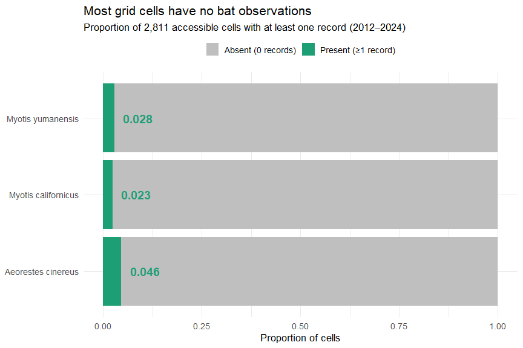

```r
pres_summary <- df %>%
  group_by(species) %>%
  summarise(
    n_cells = n(),
    n_present = sum(is_present),
    prop_present = round(mean(is_present), 3),
    .groups = "drop"
  )

df %>%
  mutate(
    status = if_else(is_present == 1, "Present (\u22651 record)", "Absent (0 records)")
  ) %>%
  count(species, status) %>%
  group_by(species) %>%
  mutate(prop = n / sum(n)) %>%
  ungroup() %>%
  ggplot(aes(x = species, y = prop, fill = status)) +
  geom_col() +
  geom_text(
    data = pres_summary,
    aes(x = species, y = prop_present, label = prop_present),
    inherit.aes = FALSE,
    hjust = -0.3, size = 5, fontface = "bold", color = "#1D9E75"
  ) +
  coord_flip() +
  scale_fill_manual(
    values = c("Present (\u22651 record)" = "#1D9E75",
               "Absent (0 records)" = "gray75")
  ) +
  labs(
    title = "Most grid cells have no bat observations",
    subtitle = "Proportion of 2,811 accessible cells with at least one record (2012\u20132024)",
    x = NULL,
    y = "Proportion of cells",
    fill = NULL
  ) +
  theme_minimal(base_size = 13) +
  theme(legend.position = "top")
```

All three species are observed in fewer than 5% of grid cells. *Aeorestes cinereus* is the most frequently observed, while *Myotis californicus* is the rarest. This extreme sparsity motivates modeling binary presence (observed or not) rather than observation counts — any count-based model would be overwhelmed by structural zeros.

### 3.2 Mapping observations over the human-modified landscape

```r
# Join covariates to the spatial grid for mapping
grid_map <- grid %>%
  mutate(cell_id = as.character(cell_id)) %>%
  left_join(
    df %>%
      mutate(cell_id = as.character(cell_id)) %>%
      distinct(cell_id, log1p_pop_density, log1p_radiance, pct_developed),
    by = "cell_id"
  )

# Ensure CRS alignment for all layers
pts_map <- st_transform(pts, st_crs(grid_map))
ca_map  <- st_transform(ca, st_crs(grid_map))
```

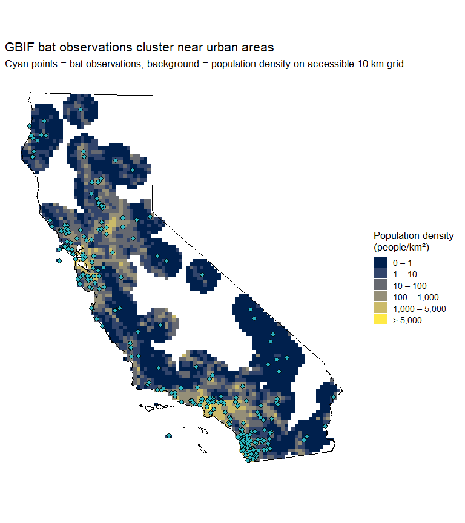

```r
# Define breaks in original units (roughly log-spaced)
pop_breaks <- c(0, 1, 10, 100, 1000, 5000, Inf)
pop_labels <- c("0 – 1", "1 – 10", "10 – 100", "100 – 1,000",
                "1,000 – 5,000", "> 5,000")

# Bin the log-transformed values using the transformed breaks
grid_map <- grid_map %>%
  mutate(
    pop_bin = cut(
      log1p_pop_density,
      breaks = log1p(pop_breaks),
      labels = pop_labels,
      include.lowest = TRUE,
      right = FALSE
    )
  )

# Viridis colors sampled at 6 evenly spaced points
bin_colors <- viridis::viridis(6, option = "cividis")

ggplot() +
  geom_sf(data = grid_map, aes(fill = pop_bin), color = NA) +
  scale_fill_manual(
    values = setNames(bin_colors, pop_labels),
    name = "Population density\n(people/km\u00B2)",
    na.value = "gray90",
    drop = FALSE
  ) +
  geom_sf(data = ca_map, fill = NA, color = "black", linewidth = 0.7) +
  geom_sf(data = pts_map, color = "black", fill = "#2CBEC9",
          shape = 21, size = 2.5, stroke = 0.6, alpha = 0.9) +
  coord_sf(datum = NA) +
  labs(
    title = "GBIF bat observations cluster near urban areas",
    subtitle = "Cyan points = bat observations; background = population density on accessible 10 km grid"
  ) +
  theme_minimal(base_size = 13) +
  theme(
    legend.position = "right",
    legend.key.height = unit(0.5, "cm")
  )
```

The map reveals a clear pattern: bat observations are concentrated in and around California’s major population centers — the San Francisco Bay Area, Los Angeles basin, San Diego, and Sacramento. Large swaths of the state’s interior, mountains, and deserts have few or no records. This is the observer bias problem in action: people (and therefore observation effort) concentrate in cities.

Maps of nighttime light radiance and percent developed land (not shown) display nearly identical spatial patterns — the same urban cores light up, the same rural areas stay dark. This visual redundancy is confirmed by the correlation analysis below.

### 3.3 Predictor correlations

```r
cov_df <- df %>%
  select(log1p_radiance, log1p_pop_density, pct_developed) %>%
  drop_na()

cor_mat <- round(cor(cov_df), 3)
cor_mat
```

[output not shown]

Nighttime light, population density, and percent developed land are all strongly correlated (r = 0.76–0.87). At 10 km resolution, these variables essentially capture the same underlying gradient of human modification. Including all three in a single model would introduce redundancy without adding predictive value — a finding that the model comparison in the next section confirms formally.

### 3.4 Presence rates along the population density gradient

To explore how bat presence varies with urban intensity, we divide population density into decile bins and compute the share of cells with at least one observation in each bin, separately by species.

```r
# Consistent species color palette used throughout
species_colors <- c(
  "Aeorestes cinereus"  = "#1B9E77",
  "Myotis yumanensis"   = "#D95F02",
  "Myotis californicus" = "#7570B3"
)
```

```r
df %>%
  mutate(bin = ntile(log1p_pop_density, 10)) %>%
  group_by(species, bin) %>%
  summarise(
    x = mean(log1p_pop_density, na.rm = TRUE),
    p = mean(is_present, na.rm = TRUE),
    .groups = "drop"
  ) %>%
  ggplot(aes(x, p, color = species)) +
  geom_line(linewidth = 1) +
  geom_point(size = 2) +
  scale_color_manual(values = species_colors) +
  theme_minimal(base_size = 13) +
  labs(
    title = "Presence rate increases with population density",
    subtitle = "Binned deciles of log(1 + population density)",
    x = "Mean log(1 + population density) within bin",
    y = "Presence rate",
    color = "Species"
  )
```

[output not shown]

Presence rates rise sharply in the upper deciles of population density, and the three species diverge: *Aeorestes cinereus* shows the steepest increase, while *Myotis californicus* responds more weakly. Equivalent plots for nighttime radiance and percent developed land (not shown) display the same qualitative pattern — unsurprising given the high correlations among these predictors. These exploratory patterns motivate the formal modeling that follows.

## 4. Model comparison: what predicts bat presence?

Given the strong collinearity among urban predictors, a natural question is: **does adding nighttime light or land development improve predictions beyond population density alone?** This matters both practically (simpler models are easier to interpret) and conceptually (if the variables are interchangeable, they’re measuring the same thing).

### 4.1 Cross-validated model comparison

We fit a series of logistic regression models predicting binary presence (`is_present`) and compare their performance using 5-fold cross-validated AUC (area under the ROC curve). Models are fit separately for each species to allow species-specific effects.

```r
# Standardize predictors for comparable coefficients
df_model <- df %>%
  mutate(
    z_radiance  = scale(log1p_radiance)[, 1],
    z_pop       = scale(log1p_pop_density)[, 1],
    z_dev       = scale(pct_developed)[, 1]
  )
```

```r
# Cross-validation helper: returns mean and SD of AUC across k folds
run_cv_model <- function(data, formula, k = 5) {
  folds <- rsample::vfold_cv(data, v = k, strata = is_present)

  results <- map_df(folds$splits, function(split) {
    train <- rsample::analysis(split)
    test  <- rsample::assessment(split)

    model <- glm(formula, data = train, family = binomial())
    probs <- predict(model, newdata = test, type = "response")
    auc_val <- pROC::auc(test$is_present, probs)

    tibble(auc = as.numeric(auc_val))
  })

  tibble(mean_auc = mean(results$auc), sd_auc = sd(results$auc))
}
```

```r
model_list <- list(
  # Single-predictor models
  S1_pop       = is_present ~ z_pop,
  S2_radiance  = is_present ~ z_radiance,
  S3_dev       = is_present ~ z_dev,

  # Population density + one additional predictor
  M1_pop_rad   = is_present ~ z_pop + z_radiance,
  M2_pop_dev   = is_present ~ z_pop + z_dev,

  # Full urban footprint
  M4_pop_rad_dev = is_present ~ z_pop + z_radiance + z_dev
)
```

```r
species_results <- df_model %>%
  group_split(species) %>%
  map_df(function(sp_data) {
    sp_name <- unique(sp_data$species)
    map_df(names(model_list), function(mname) {
      cv_res <- run_cv_model(sp_data, model_list[[mname]])
      tibble(
        species  = sp_name,
        model    = mname,
        mean_auc = cv_res$mean_auc,
        sd_auc   = cv_res$sd_auc
      )
    })
  })
```

```r
# Key comparison: population density alone vs. additive models
species_results %>%
  filter(model %in% c("S1_pop", "M1_pop_rad", "M2_pop_dev", "M4_pop_rad_dev")) %>%
  mutate(
    model = recode(model,
      "S1_pop"         = "Pop. density only",
      "M1_pop_rad"     = "+ radiance",
      "M2_pop_dev"     = "+ development",
      "M4_pop_rad_dev" = "+ radiance + development"
    )
  ) %>%
  select(species, model, mean_auc, sd_auc) %>%
  arrange(species, desc(mean_auc))
```

[output not shown]

```r
species_results %>%
  filter(model %in% c("S1_pop", "M1_pop_rad", "M2_pop_dev", "M4_pop_rad_dev")) %>%
  mutate(
    model = recode(model,
      "S1_pop"         = "Pop. density only",
      "M1_pop_rad"     = "+ nighttime light",
      "M2_pop_dev"     = "+ developed land",
      "M4_pop_rad_dev" = "+ light + development"
    ),
    model = factor(model, levels = c(
      "+ light + development",
      "+ developed land",
      "+ nighttime light",
      "Pop. density only"
    )),
    highlight = model == "Pop. density only"
  ) %>%
  ggplot(aes(x = mean_auc, y = model, fill = highlight)) +
  geom_col(width = 0.7) +
  geom_text(
    aes(label = sprintf("%.3f", mean_auc)),
    hjust = -0.15, size = 3.5
  ) +
  scale_fill_manual(
    values = c("TRUE" = "#E63946", "FALSE" = "gray50"),
    guide = "none"
  ) +
  facet_wrap(~ species) +
  coord_cartesian(xlim = c(0.5, 1.0)) +
  labs(
    title = "Population density alone is nearly as predictive as multi-variable models",
    subtitle = "5-fold cross-validated AUC by species",
    x = "Mean AUC",
    y = NULL
  ) +
  theme_minimal(base_size = 12) +
  theme(
    panel.grid.major.y = element_blank(),
    strip.text = element_text(face = "italic", size = 11)
  )
```

[output not shown]

### 4.2 Key finding: urban predictors are redundant at this scale

Population density alone achieves cross-validated AUC scores of approximately 0.76–0.80 depending on species. Adding nighttime light radiance, percent developed land, or both improves AUC by less than 1 percentage point in every case. At 10 km resolution, these variables are effectively measuring the same underlying gradient of human modification — they are interchangeable as predictors of bat presence.

This does not mean light and development are ecologically irrelevant. It means that at this spatial scale, with opportunistic data, their effects cannot be separated from the broader urban intensity signal. A finer-resolution study with systematic survey data might be able to tease them apart.

For the remaining analysis, we use **population density as the single urban intensity predictor** — it is the most parsimonious, has the clearest dual interpretation (accessibility proxy + human footprint), and performs as well as any combination.

## 5. Do species respond differently to the urban gradient?

The EDA and model comparison established that population density captures the dominant signal in these data. The next question is whether species differ in *how strongly* they respond to that gradient.

### 5.1 Species × population density interaction model

```r
# Factor species for interaction modeling
df_model <- df_model %>%
  mutate(species = factor(species))

# Fit interaction model: allows each species a different intercept and slope
model_interaction <- glm(
  is_present ~ species * z_pop,
  data = df_model,
  family = binomial()
)

summary(model_interaction)
```

### 5.2 Model comparison: does the interaction matter?

```r
model_pop         <- glm(is_present ~ z_pop, data = df_model, family = binomial())
model_pop_species <- glm(is_present ~ z_pop + species, data = df_model, family = binomial())

tibble(
  Model = c("Pop. density only",
            "Pop. + species (additive)",
            "Species \u00d7 pop. (interaction)"),
  AIC   = c(AIC(model_pop),
            AIC(model_pop_species),
            AIC(model_interaction)),
  df    = c(model_pop$df.residual,
            model_pop_species$df.residual,
            model_interaction$df.residual)
) %>%
  mutate(delta_AIC = AIC - min(AIC))
```

[output not shown]

The interaction model provides the best fit (lowest AIC), confirming that species differ not just in baseline presence rates but in the strength of their association with population density.

### 5.3 Species-specific slopes and odds ratios

```r
coefs    <- coef(model_interaction)
vcov_mat <- vcov(model_interaction)

# Helper: extract species-specific slope and standard error
get_species_slope <- function(sp) {
  if (sp == "Aeorestes cinereus") {
    slope <- coefs["z_pop"]
    var   <- vcov_mat["z_pop", "z_pop"]
  } else {
    int_term <- paste0("species", sp, ":z_pop")
    slope <- coefs["z_pop"] + coefs[int_term]
    var   <- vcov_mat["z_pop", "z_pop"] +
             vcov_mat[int_term, int_term] +
             2 * vcov_mat["z_pop", int_term]
  }
  tibble(species = sp, log_odds_slope = slope, se = sqrt(var))
}

or_results <- bind_rows(
  get_species_slope("Aeorestes cinereus"),
  get_species_slope("Myotis californicus"),
  get_species_slope("Myotis yumanensis")
) %>%
  mutate(
    odds_ratio = exp(log_odds_slope),
    lower_ci   = exp(log_odds_slope - 1.96 * se),
    upper_ci   = exp(log_odds_slope + 1.96 * se)
  )

or_results
```

[output not shown]

```r
ggplot(or_results, aes(x = odds_ratio, y = species)) +
  geom_vline(xintercept = 1, linetype = "dashed", color = "gray50") +
  geom_point(size = 3) +
  geom_errorbarh(aes(xmin = lower_ci, xmax = upper_ci), height = 0.2) +
  labs(
    title = "All three species show positive urban associations, but magnitudes differ",
    subtitle = "Odds ratio per 1 SD increase in log(population density), 95% CI",
    x = "Odds ratio",
    y = NULL
  ) +
  theme_minimal(base_size = 13) +
  theme(axis.text.y = element_text(face = "italic"))
```

[output not shown]

All three species have odds ratios significantly greater than 1, meaning the probability of observing any of them increases with population density. However, the magnitude of the effect differs: *Aeorestes cinereus* and *Myotis yumanensis* show the strongest associations, while *Myotis californicus* shows a notably weaker response to the urban gradient.

### 5.4 Predicted probability curves

The most interpretable summary of the interaction model is a plot of predicted presence probability across the population density gradient, with the x-axis back-transformed to real-world units.

```r
# Back-transformation from z-score to population density
mu  <- mean(df_model$log1p_pop_density)
sig <- sd(df_model$log1p_pop_density)
z_to_pop <- function(z) exp((z * sig) + mu) - 1

# Build prediction grid
pred_grid <- expand.grid(
  z_pop   = seq(min(df_model$z_pop), max(df_model$z_pop), length.out = 200),
  species = levels(df_model$species)
)
pred_grid$pred_prob <- predict(
  model_interaction, newdata = pred_grid, type = "response"
)

# Reorder species for legend clarity
pred_grid$species <- factor(pred_grid$species, levels = c(
  "Aeorestes cinereus",
  "Myotis yumanensis",
  "Myotis californicus"
))

ggplot(pred_grid, aes(z_pop, pred_prob, color = species)) +
  geom_line(linewidth = 2) +
  scale_color_manual(values = species_colors) +
  scale_x_continuous(
    name = "Population density (people per km\u00B2, log-scaled)",
    labels = function(x) format(round(z_to_pop(x)), big.mark = ",")
  ) +
  labs(
    title = "Species differ in their association with the human-modified landscape gradient",
    subtitle = "Predicted probability of presence from species \u00d7 population density interaction model",
    y = "Predicted probability of presence",
    color = "Species"
  ) +
  theme_minimal(base_size = 13) +
  theme(
    plot.title = element_text(size = 15, face = "bold"),
    axis.line = element_line(linewidth = 0.8, color = "black"),
    panel.grid.major = element_line(linewidth = 0.5, color = "gray85"),
    panel.grid.minor = element_blank(),
    legend.position = c(0.25, 0.80),
    legend.background = element_rect(fill = "white", color = "gray85"),
    legend.text = element_text(face = "italic")
  )
```

[output not shown]

- **All three species** have higher predicted presence probability in more urbanized areas, consistent with observer bias driving the overall pattern.
- *Aeorestes cinereus* shows the highest predicted probabilities across the gradient, reaching approximately 30% in the most densely populated cells.
- *Myotis californicus* shows the weakest response — its predicted probability curve rises more slowly and remains lower than the other two species even at high population densities.
- The **divergence between species** is the ecologically interesting signal. Even though observer bias inflates all three curves, the *relative differences* between species are informative: they suggest that *Myotis californicus* may be more sensitive to urbanization, or at least less associated with human-modified landscapes, than the other two species.

## 6. Discussion

### 6.1 Summary of findings

This analysis used 455 GBIF bat occurrence records across three focal species, mapped onto a 10 km equal-area grid covering accessible regions of California, to examine how components of the human-modified landscape structure bat observation patterns. Three main findings emerged:

1. **Population density alone is sufficient to predict bat presence at this scale.** Nighttime light radiance and percent developed land are strongly collinear with population density at 10 km resolution and add negligible predictive value (less than 1% AUC improvement). At this scale, these variables function as interchangeable urban intensity proxies.
2. **All three species show positive associations with increasing urban intensity.** This is expected given the opportunistic nature of GBIF data — more people means more observers means more bat records, regardless of true ecological preference.
3. **Species differ in the strength of their urban association.** *Myotis californicus* shows a significantly weaker association with population density than either *Aeorestes cinereus* or *Myotis yumanensis*. This species-level difference persists even after accounting for the shared effect of observer bias, suggesting a genuine ecological signal: *Myotis californicus* may be more sensitive to urbanization or less tolerant of human-modified landscapes.

### 6.2 The dual role of population density

Population density plays two roles in this analysis, and the tension between them is worth making explicit. First, it serves as an **accessibility proxy**: areas with more people have more observers, so GBIF records are biased toward populated areas. Second, it serves as a **human footprint measure**: population density genuinely correlates with habitat modification, light pollution, noise, and other stressors that affect bat ecology.

These roles cannot be fully separated with opportunistic data. The fact that all three species show positive associations with population density likely reflects both accessibility bias and some degree of genuine urban tolerance. The more informative result is the *difference* between species: if all three were equally biased by observer effort, their curves would be parallel. The fact that *Myotis californicus* diverges suggests something ecologically real.

### 6.3 Limitations and future directions

- **Observer bias remains the dominant confound.** Without systematic survey data (e.g., acoustic monitoring arrays with standardized effort), it is not possible to determine whether species are truly more common near urban areas or simply more frequently reported there.
- **Spatial autocorrelation is not modeled.** Nearby grid cells are likely more similar than distant ones, violating the independence assumption of standard logistic regression. A spatial model (e.g., using INLA or spatial random effects) could account for this.
- **Temporal dynamics are collapsed.** Aggregating across 2012–2024 treats presence as static, which obscures potential range shifts or changes in observation effort over time.
- **Sample size is modest.** With 455 total records (and only 114 for *Myotis californicus*), effect estimates carry substantial uncertainty. Additional data sources (e.g., iNaturalist, state wildlife agency databases) could improve statistical power.

Despite these limitations, the analysis demonstrates a reproducible framework for using open biodiversity data to detect species-specific responses to landscape modification — an approach that scales to other taxa and regions.

## 7. Data sources and citations

| Dataset | Source | Access |
| --- | --- | --- |
| Bat occurrence records | GBIF (2012–2024) | [gbif.org](https://www.gbif.org/) |
| Nighttime light radiance | VIIRS VNL v2.1/v2.2, EOG Payne Institute | [eogdata.mines.edu](https://eogdata.mines.edu/products/vnl/) |
| Land cover | NLCD 2019 | [mrlc.gov](https://www.mrlc.gov/) |
| Protected areas | PAD-US 4.1 | [usgs.gov/programs/gap-analysis-project](https://www.usgs.gov/programs/gap-analysis-project/science/pad-us-data-download) |
| Population density | GPWv4 rev. 11 (SEDAC/CIESIN) 2020 | [earthdata.nasa.gov](https://www.earthdata.nasa.gov/data/catalog/sedac-ciesin-sedac-gpwv4-popdens-r11-4.11) |
| State boundary | US Census TIGER/Line | via `tigris` R package |